# Algoritmo para la estimación de la turbidez sobre el Río Paraná

Autor/a

Afiliación

Víctor Gustavo Gómez

[GISTAQ (UTN-FRRe)](https://www.instagram.com/gistaq.utn/)

Fecha de publicación

8 de octubre de 2026

Resumen

Este sitio web contiene información sobre la estimación de la turbidez por teledetección en la cuenca media del Río Paraná. La turbidez es uno parámetros de interés dentro proyecto Estimar indicadores de calidad de agua en la cuenca media del río Paraná para el desarrollo de un algoritmo mediante técnicas de teledetección satelital (MSECRE0008604), desarrollado por el Grupo de Investigación Sobre Temas Ambientales y Químicos (GISTAQ) de la Universidad Tecnológica Nacional Facultad Regional Resistencia (UTN-FRRe).

Se utilizarán imágenes del satélite Sentinel-2 con corrección automática, de las cuales se obtiene la reflectancia de superficie del agua. Se buscará la relación entre la reflectancia y la turbidez por métodos de regresión tradionales y machine learning. Una vez obtenido el algoritmo que relacione ambas propiedades, se desarrollaran mapas de distribución espacial.

Palabras clave

GISTAQ, UTN, FRRe, Algoritmo, Turbidez, Machine learning, Teledetección

# 1 Modelo XGBoost optimizado con Optuna (Búsqueda bayesiana inteligente)

Tabla con hiperparámetros optimizados

|  | max_depth | learning_rate | subsample | colsample_bytree | n_estimators | R2_promedio_CV |
| --- | --- | --- | --- | --- | --- | --- |
| 0 | 9 | 0.042543 | 0.751347 | 0.892266 | 649 | 0.924281 |

Cargo modelo entrenado

Métricas de desempeño

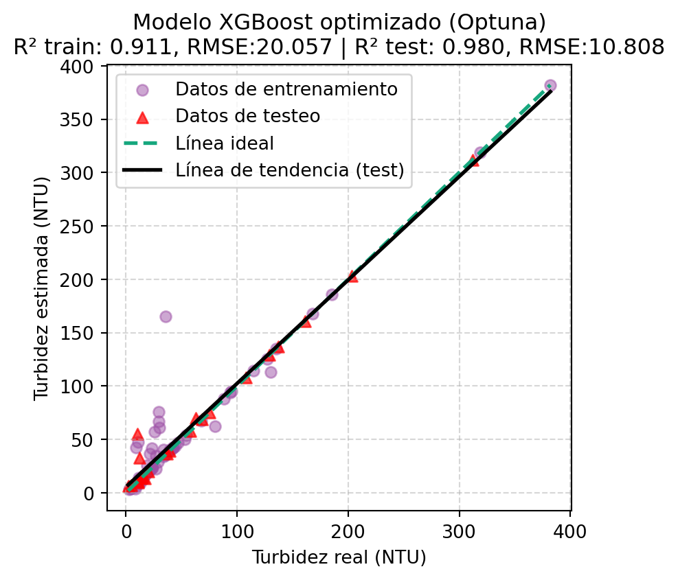

**Mapas XGBoost Optuna**

```
Se procesaron 8 archivos .tif
```

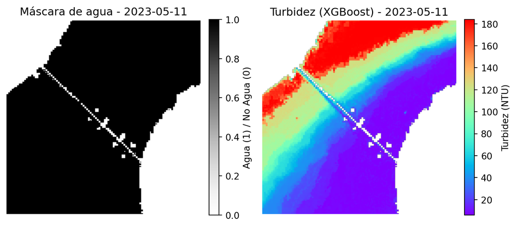

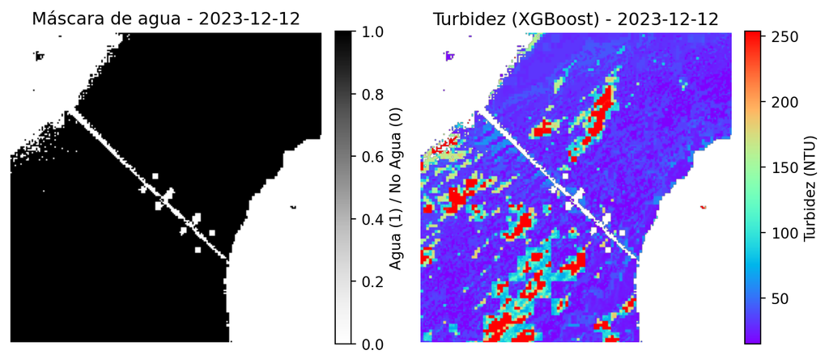

[figure not shown]

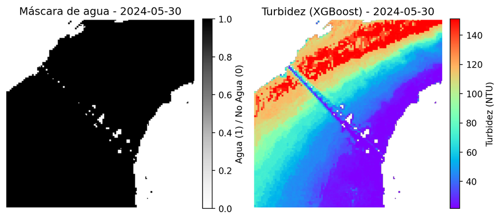

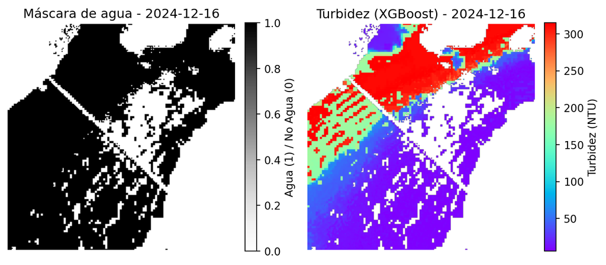

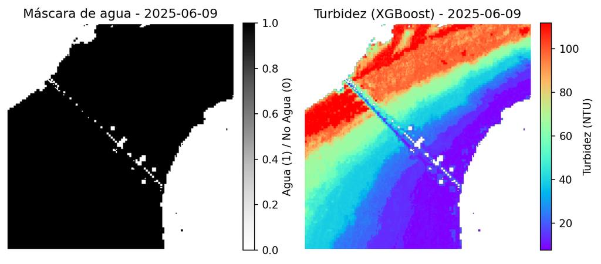

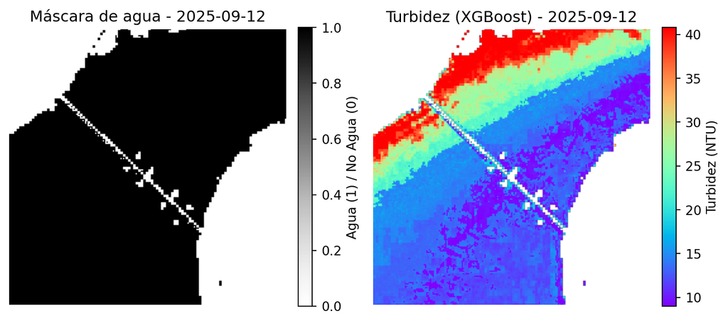

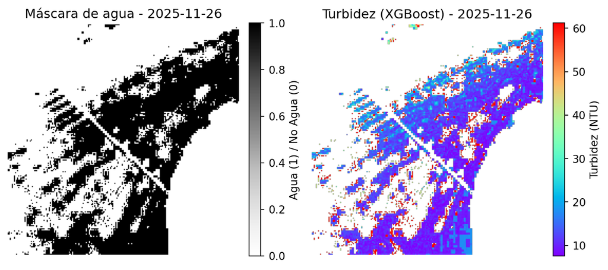

# 2 Relevancia de Bandas espectrales en el modelo XGBOOST

La importancia de las bandas indica cuánto contribuye cada banda espectral (o combinación de ellas) al rendimiento del modelo. Esto permite saber cuáles longitudes de onda son más informativas para estimar la variable objetivo.

Interpretación:

Cuanto mayor sea la importancia, más influye esa banda en las divisiones del modelo.

No necesariamente significa correlación directa (puede ser no lineal).

Si una banda tiene muy baja importancia (≈0), puede eliminarse en futuras versiones del modelo para simplificarlo.

Cuando entrenás un modelo como XGBoost, el algoritmo aprende qué variables (bandas espectrales) son más útiles para predecir la turbidez.

• La importancia de las bandas indica cuánto aportó cada banda al modelo para mejorar sus predicciones.

En XGBoost, el atributo model.feature_importances_ mide la importancia promedio de cada variable dentro de todos los árboles del modelo.

XGBoost da la importancia relativa (no absoluta ni porcentual) basada en “weight”. Los valores se normalizan para que la suma de todos sea 1.0.

| Tipo de importancia (`importance_type`) | Qué mide exactamente | Interpretación práctica |
| --- | --- | --- |
| `"weight"` *(por defecto)* | Número de veces que la variable fue usada para dividir nodos | Bandas usadas más veces para tomar decisiones |
| `"gain"` | Promedio de la mejora en la predicción al usar esa banda | Cuánto “valor” aporta cada vez que se usa |
| `"cover"` | Promedio de la cantidad de datos afectados por esas divisiones | Qué tan general es su influencia |
| `"total_gain"` o `"total_cover"` | Suma total de las métricas anteriores | Importancia acumulada |

**Importancia de cada banda dentro del modelo XGBoost**

|  | Banda | Importancia |
| --- | --- | --- |
| 0 | B05 | 0.594959 |
| 1 | B06 | 0.146968 |
| 2 | B01 | 0.055881 |
| 3 | B02 | 0.053704 |
| 4 | B08 | 0.046594 |
| 5 | B8A | 0.046546 |
| 6 | B07 | 0.037112 |
| 7 | B03 | 0.009663 |
| 8 | B04 | 0.003476 |
| 9 | B11 | 0.002844 |
| 10 | B12 | 0.002254 |

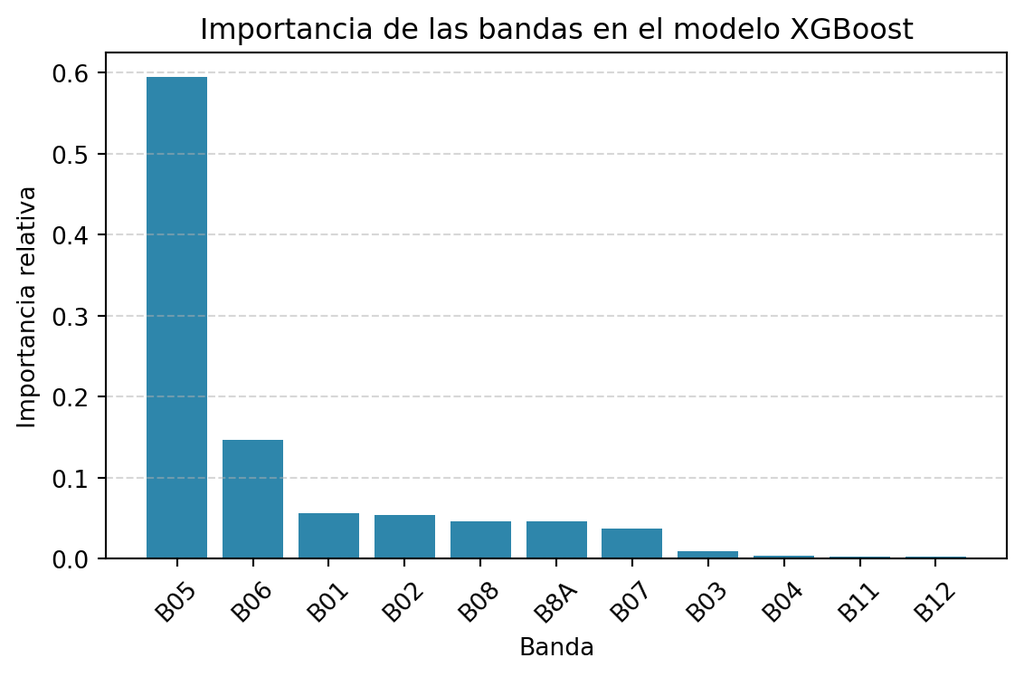

El análisis de importancia de características del modelo XGBoost optimizado muestra una dominancia muy marcada de la banda B05, que concentra cerca del 60% de la importancia total. Esto indica que, para el modelo, la información contenida en B05 es el factor más determinante para estimar la turbidez.

En segundo lugar aparece la banda B06, con una importancia mucho menor pero aún relevante aproximadamente 15%. Después de estas dos, el resto de las bandas (B01, B02, B08, B8A, B07) aportan importancias moderadas y similares entre sí, lo que indica que contribuyen al modelo pero de forma secundaria.

Por otro lado, algunas bandas como B03, B04, B11 y B12 tienen una importancia prácticamente nula, lo que sugiere que su aporte al modelo es mínimo. Esto podría deberse a que estas bandas no contienen información útil para diferenciar niveles de turbidez o dicha información está fuertemente correlacionada con otras bandas más relevantes.

El modelo depende fuertemente de un conjunto reducido de bandas, especialmente B05.

La alta concentración de importancia en pocas bandas sugiere que la señal espectral relacionada con la turbidez está localizada en rangos específicos del espectro.

Las bandas con importancia mínima podrían ser candidatas para eliminación en futuros experimentos, lo que implicaría: -Modelos más ligeros -Menor costo computacional -Potencialmente mejorar generalización al reducir ruido

# 3 Conclusión

El análisis realizado demuestra que la estimación de turbidez a partir de bandas espectrales Sentinel-2 presenta un buen potencial predictivo, pero la capacidad del modelo depende fuertemente del tipo de algoritmo utilizado.

El XGBoost optimizado ofrece una mejora clara en desempeño, captura relaciones no lineales y reduce significativamente el error, mostrando ser el enfoque más adecuado para el problema.

La combinación de optimización automática (Optuna) y un algoritmo avanzado de ensamble permite obtener un modelo robusto y reproducible, adaptable a distintos conjuntos de datos y con potencial para implementarse operativamente.

# 4 Documentación

Modelo XGBoost: https://xgboost.ai

Optimazador de hiper parámetro Optuna: https://optuna.org/